# Problem Set 2

#### Part B

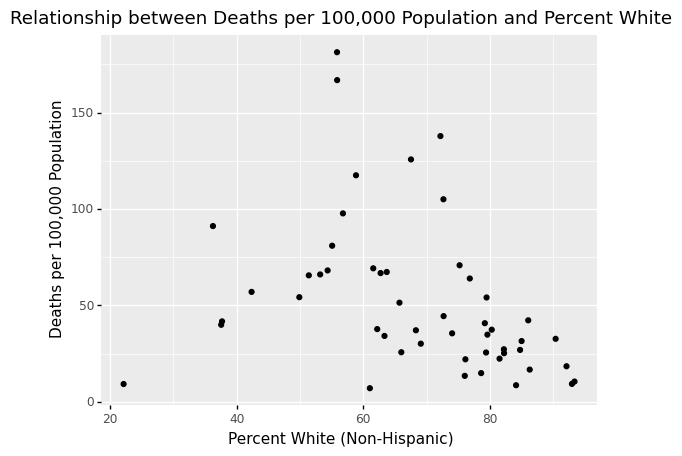

```python
#In terms of absolutes, Pct_white_non_hispanic is most correlated with deaths per 100k
#Plot scatter plot of Pct_white_non_hispanic against deaths per 100k

(
    ggplot(final,aes(x = "Pct_White_Non_Hispanic",y='total_deaths_per100k')) +
    geom_point() + labs(x = "Percent White (Non-Hispanic)", y = "Deaths per 100,000 Population")
    + ggtitle("Relationship between Deaths per 100,000 Population and Percent White")
)
```

## Part 2

### Question 1

```python
us_states.head()
```

|  | date | state | fips | cases | deaths |
| --- | --- | --- | --- | --- | --- |
| 0 | 2020-01-21 | Washington | 53 | 1 | 0 |
| 1 | 2020-01-22 | Washington | 53 | 1 | 0 |
| 2 | 2020-01-23 | Washington | 53 | 1 | 0 |
| 3 | 2020-01-24 | Illinois | 17 | 1 | 0 |
| 4 | 2020-01-24 | Washington | 53 | 1 | 0 |

```python
#Group by state and use diff function to calculate difference in cases in each row for every state
us_states['new_cases']= us_states.groupby(['state']).cases.diff()

#first value of each state returns na, so replace with cases on that day
us_states['new_cases'] = us_states.new_cases.fillna(us_states.cases)

#pull date and month
us_states['date'] = pd.to_datetime(us_states['date'] , format='%Y-%m-%d')
us_states['month'] = pd.DatetimeIndex(us_states['date']).month

#filter new cases in september (includes new cases on Sept 1)
#group by state and sum new cases
sept_us_covid = us_states[us_states['month'] == 9].groupby(['state'])['new_cases'].sum().reset_index()

#merge on state population
sept_us_covid = pd.merge(sept_us_covid,final[['state','State_Population']],on='state', how='left')

#calculate new cases per 100 k by multiplying by 100k and dividing by population
sept_us_covid['new_cases_per_100k'] = sept_us_covid['new_cases']*100000/sept_us_covid['State_Population']

#sort by new cases per 100 k in descending order and display top state
sept_us_covid.sort_values(by = ['new_cases_per_100k'], ascending=False).head(1)
```

|  | state | new_cases | State_Population | new_cases_per_100k |
| --- | --- | --- | --- | --- |
| 35 | North Dakota | 9166.0 | 752201.0 | 1218.557274 |

### Question 2

```python
#Note to TA/Prof Dunford:
#I already calculated daily new cases in the code chunk above

#Group by state and use diff function to calculate difference in deaths in each row for every state
us_states['new_deaths']= us_states.groupby(['state']).deaths.diff()

#first value of each state returns na, so replace with deaths on that day
us_states['new_deaths'] = us_states.new_deaths.fillna(us_states.deaths)
us_states.head()
```

|  | date | state | fips | cases | deaths | new_cases | month | new_deaths |
| --- | --- | --- | --- | --- | --- | --- | --- | --- |
| 0 | 2020-01-21 | Washington | 53 | 1 | 0 | 1.0 | 1 | 0.0 |
| 1 | 2020-01-22 | Washington | 53 | 1 | 0 | 0.0 | 1 | 0.0 |
| 2 | 2020-01-23 | Washington | 53 | 1 | 0 | 0.0 | 1 | 0.0 |
| 3 | 2020-01-24 | Illinois | 17 | 1 | 0 | 1.0 | 1 | 0.0 |
| 4 | 2020-01-24 | Washington | 53 | 1 | 0 | 0.0 | 1 | 0.0 |

```python
#summarize daily new cases
us_states.new_cases.describe()
```

```
count    11564.000000
mean       620.586821
std       1293.787065
min      -7757.000000
25%         36.000000
50%        222.000000
75%        683.250000
max      22276.000000
Name: new_cases, dtype: float64
```

```python
#summarize daily new deaths
us_states.new_deaths.describe()
```

```
count    11564.000000
mean        17.722328
std         55.748189
min       -102.000000
25%          0.000000
50%          4.000000
75%         15.000000
max       1877.000000
Name: new_deaths, dtype: float64
```

### Question 3

```python
final.groupby(['state']).effective_end.max().head(15)
#Choose Illinois as state which had a stay at home order that expired (before September 28)
```

```
state
Alabama                 4/30/2020
Alaska                  4/24/2020
Arizona                 5/15/2020
Arkansas                      NaN
California              9/28/2020
Colorado                4/26/2020
Connecticut             5/20/2020
Delaware                5/31/2020
District of Columbia    5/15/2020
Florida                 4/30/2020
Georgia                 4/30/2020
Hawaii                  5/31/2020
Idaho                   4/30/2020
Illinois                5/31/2020
Indiana                  5/1/2020
Name: effective_end, dtype: object
```

```python
#Merge stay at home order dates for each state

us_states = pd.merge(us_states,final[['state','effective_start']],on='state', how='left')
us_states = pd.merge(us_states,final[['state','effective_end']],on='state', how='left')
us_states.head()
```

|  | date | state | fips | cases | deaths | new_cases | month | new_deaths | effective_start | effective_end |
| --- | --- | --- | --- | --- | --- | --- | --- | --- | --- | --- |
| 0 | 2020-01-21 | Washington | 53 | 1 | 0 | 1.0 | 1 | 0.0 | 3/25/2020 | 5/31/2020 |
| 1 | 2020-01-22 | Washington | 53 | 1 | 0 | 0.0 | 1 | 0.0 | 3/25/2020 | 5/31/2020 |
| 2 | 2020-01-23 | Washington | 53 | 1 | 0 | 0.0 | 1 | 0.0 | 3/25/2020 | 5/31/2020 |
| 3 | 2020-01-24 | Illinois | 17 | 1 | 0 | 1.0 | 1 | 0.0 | 3/25/2020 | 5/31/2020 |
| 4 | 2020-01-24 | Washington | 53 | 1 | 0 | 0.0 | 1 | 0.0 | 3/25/2020 | 5/31/2020 |

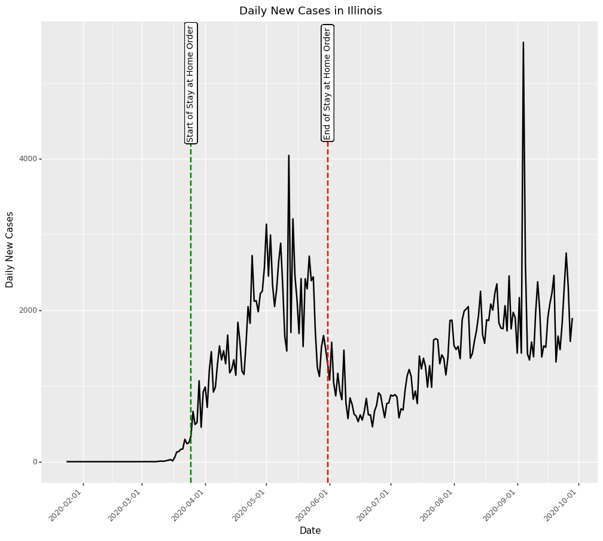

```python
# Examine trends for specific state.

# Break up by state
d = us_states.query("state == 'Illinois'")

(
  ggplot(d,aes(x = "date",y='new_cases')) +
  geom_path(size=1) + theme(figure_size = (12, 10), axis_text_x  = element_text(angle = 45, hjust = 1))
    + ggtitle("Daily New Cases in Illinois")
    + geom_vline(xintercept = pd.to_datetime(d["effective_start"], format='%m/%d/%Y').min(), color = "green", linetype = "dashed", size = 1)
    + geom_label(x = pd.to_datetime(d["effective_start"], format='%m/%d/%Y').min(), y=5000, label = "Start of Stay at Home Order", size=10, angle=90)
    + geom_vline(xintercept = pd.to_datetime(d["effective_end"], format='%m/%d/%Y').min(), color = "red", linetype = "dashed", size = 1)
    + geom_label(x = pd.to_datetime(d["effective_end"], format='%m/%d/%Y').min(), y=5000, label = "End of Stay at Home Order", size=10, angle=90)
    + labs(x = "Date", y = "Daily New Cases")
)
```

In Illinois, after the stay at home order ended, covid cases continued to decline for a few weeks (potentially because of the three month cycle covid seems to follow, or because the the spread of cases would lag behind the initial opening). However, the decline in cases slowed down and eventually reversed. Starting in July, daily cases began to rise again.

### Question 4

```python
#Merge on indicator for whether or not trump won, and state population, by state

us_states = pd.merge(us_states,final[['state','trump_won']],on='state', how='left')
us_states = pd.merge(us_states,final[['state','State_Population']],on='state', how='left')
us_states.head()
```

|  | date | state | fips | cases | deaths | new_cases | month | new_deaths | effective_start | effective_end | trump_won | State_Population |
| --- | --- | --- | --- | --- | --- | --- | --- | --- | --- | --- | --- | --- |
| 0 | 2020-01-21 | Washington | 53 | 1 | 0 | 1.0 | 1 | 0.0 | 3/25/2020 | 5/31/2020 | No | 7294336.0 |
| 1 | 2020-01-22 | Washington | 53 | 1 | 0 | 0.0 | 1 | 0.0 | 3/25/2020 | 5/31/2020 | No | 7294336.0 |
| 2 | 2020-01-23 | Washington | 53 | 1 | 0 | 0.0 | 1 | 0.0 | 3/25/2020 | 5/31/2020 | No | 7294336.0 |
| 3 | 2020-01-24 | Illinois | 17 | 1 | 0 | 1.0 | 1 | 0.0 | 3/25/2020 | 5/31/2020 | No | 12821497.0 |
| 4 | 2020-01-24 | Washington | 53 | 1 | 0 | 0.0 | 1 | 0.0 | 3/25/2020 | 5/31/2020 | No | 7294336.0 |

```python
#group by date and trump_won
#for each date, for states that trump won (or didnt), sum new cases, deaths and populations of states

df_by_winner = us_states.groupby(['date','trump_won'])[['new_cases', 'new_deaths', 'State_Population']].sum().reset_index()

#convert new cases and new deaths to per 100,000 population
df_by_winner['new_cases_per_100k'] = df_by_winner['new_cases']*100000/df_by_winner['State_Population']
df_by_winner['new_deaths_per_100k'] = df_by_winner['new_deaths']*100000/df_by_winner['State_Population']
df_by_winner.head(1000)
```

|  | date | trump_won | new_cases | new_deaths | State_Population | new_cases_per_100k | new_deaths_per_100k |
| --- | --- | --- | --- | --- | --- | --- | --- |
| 0 | 2020-01-21 | No | 1.0 | 0.0 | 7294336.0 | 0.013709 | 0.000000 |
| 1 | 2020-01-22 | No | 0.0 | 0.0 | 7294336.0 | 0.000000 | 0.000000 |
| 2 | 2020-01-23 | No | 0.0 | 0.0 | 7294336.0 | 0.000000 | 0.000000 |
| 3 | 2020-01-24 | No | 1.0 | 0.0 | 20115833.0 | 0.004971 | 0.000000 |
| 4 | 2020-01-25 | No | 1.0 | 0.0 | 59264593.0 | 0.001687 | 0.000000 |
| ... | ... | ... | ... | ... | ... | ... | ... |
| 494 | 2020-09-26 | Yes | 29052.0 | 589.0 | 182739463.0 | 15.898044 | 0.322317 |
| 495 | 2020-09-27 | No | 10481.0 | 90.0 | 140163567.0 | 7.477692 | 0.064211 |
| 496 | 2020-09-27 | Yes | 25960.0 | 175.0 | 182739463.0 | 14.206017 | 0.095765 |
| 497 | 2020-09-28 | No | 11812.0 | 118.0 | 140163567.0 | 8.427297 | 0.084187 |
| 498 | 2020-09-28 | Yes | 24234.0 | 221.0 | 182739463.0 | 13.261503 | 0.120937 |

499 rows × 7 columns

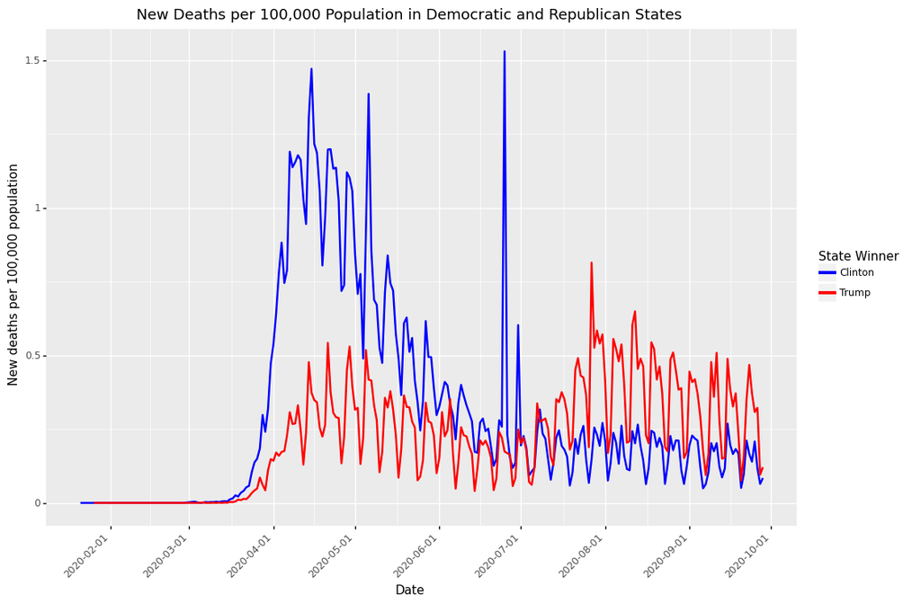

```python
#plot by trump_won and manually set colors

(
  ggplot(df_by_winner, aes(x = 'date',y='new_deaths_per_100k',color="trump_won"))
    + geom_path(size=1)
    + ggtitle ("New Deaths per 100,000 Population in Democratic and Republican States")
    + theme(figure_size = (12, 8), axis_text_x  = element_text(angle = 45, hjust = 1))
    + scale_color_manual(name = "State Winner", labels = ("Clinton", "Trump"), values=("blue", "red"))
    + labs(x = "Date", y = "New deaths per 100,000 population")
)
```

In the early days of the pandemic, deaths disproportionately impacted blue states (possibly because blue states were more likely to have large cities where transmission was higher). However, starting in July, deaths in red states overtook blue states (possibly due to resistance against mask mandates and other restrictions in these states).